# Линейная регрессия: часть 3

Зарманбетов Ахмед

```r
library(tibble)
library(dplyr)
library(tidyr)
library(ggplot2)
```

### Прогноз

Когда мы построили модель, мы можем использовать ее для предсказания. Это можно сделать с помощью функции `predict`.

```r
set.seed(42)
n <- 50
data <- tibble(education = seq(7, 20, length.out = n) + rnorm(n, sd = 2),
               income = 10000 + 5000 * education + rnorm(n, sd = 5000))
```

```r
model <- lm(income ~ education, data = data)
model
```

```
##
## Call:
## lm(formula = income ~ education, data = data)
##
## Coefficients:
## (Intercept)    education
##       13964         4742
```

```r
data$pred_income <- predict(model, data)
data$pred_income
```

```
##  [1]  60163.22  43062.50  53120.69  56937.17  56027.20  52444.50  69045.35
##  [8]  55069.56  76369.41  57888.86  72117.97  82687.85  49085.40  60872.12
## [15]  63509.97  72064.34  64594.76  43353.60  46660.31  83585.96  69415.08
## [22]  56686.62  73209.16  87618.55  95331.14  74531.38  77432.27  64407.67
## [29]  86752.50  77576.75  89224.74  92848.22  97238.82  82904.05  94726.90
## [36]  74910.68  85013.67  85641.60  72072.52  96571.01  99440.37  95320.25
## [43] 107193.73  94368.55  89541.63 107882.44  97339.79 119990.35 103459.74
## [50] 115028.52
```

### Графическая иллюстрация модели

Когда признаков много, невозможно представить себе многомерное пространство. Нарисовать это тоже невозможно. Но можно посмотреть на то, как работает модель. Попробуем отложить по оси $X$ наш прогноз, а по оси $Y$ реальное значение. Идеально спрогнозированные наблюдения лежат на прямой $Y = X$.

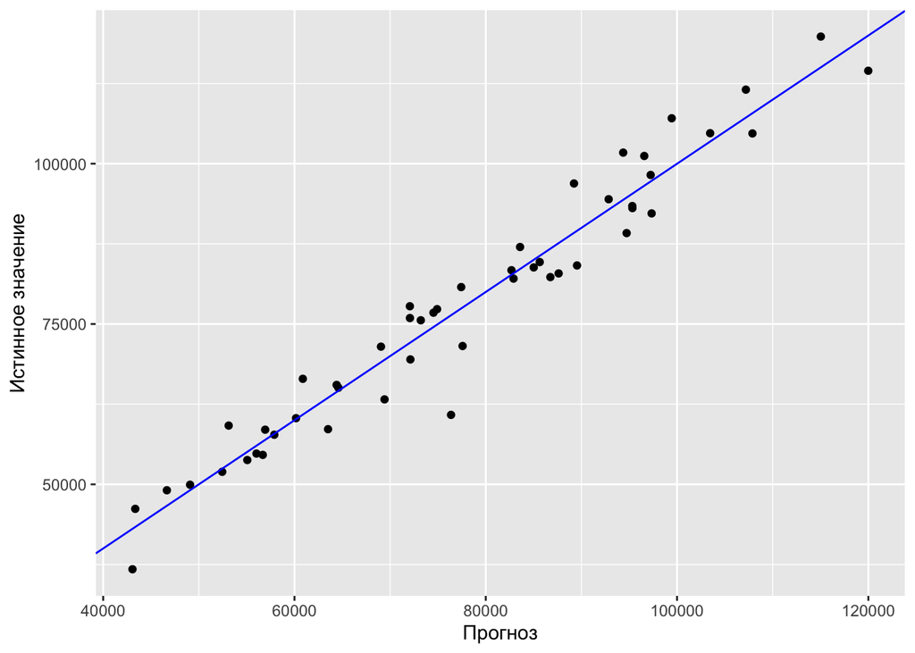

```r
ggplot(data, aes(x = pred_income, y = income)) +
  geom_point() +
  geom_abline(color = "blue") +
  xlab('Прогноз') +
  ylab('Истинное значение')
```

На этом графике можно видеть недопрогноз и перепрогноз.

### Метрики качества

Чтобы оценить насколько хорошо отработала модель нужна какая-то мера качества модели. Для задачи регрессии основными являются:

1. RMSE

$$RMSE = \sqrt{\frac{1}{n} \sum_{i=1}^{n} (y_i - \hat y_i)^2}$$

2. MAE

$$MAE = \frac{1}{n} \sum_{i=1}^{n} |y_i - \hat y_i|$$

3. MAPE

$$MAPE = \frac{1}{n} \sum_{i=1}^{n} |\frac{y_i - \hat y_i}{y_i}|$$

```r
library(Metrics)

rmse(data$income, data$pred_income)
```

```
## [1] 4458.386
```

```r
mae(data$income, data$pred_income)
```

```
## [1] 3514.527
```

Чтобы понять много это или мало нужно понять чему равно среднее значение таргета.

```r
mean(data$income)
```

```
## [1] 77646.79
```

```r
mape(data$income, data$pred_income)
```

```
## [1] 0.04743514
```

### Нелинейная зависимость

Не всегда зависимости линейны.

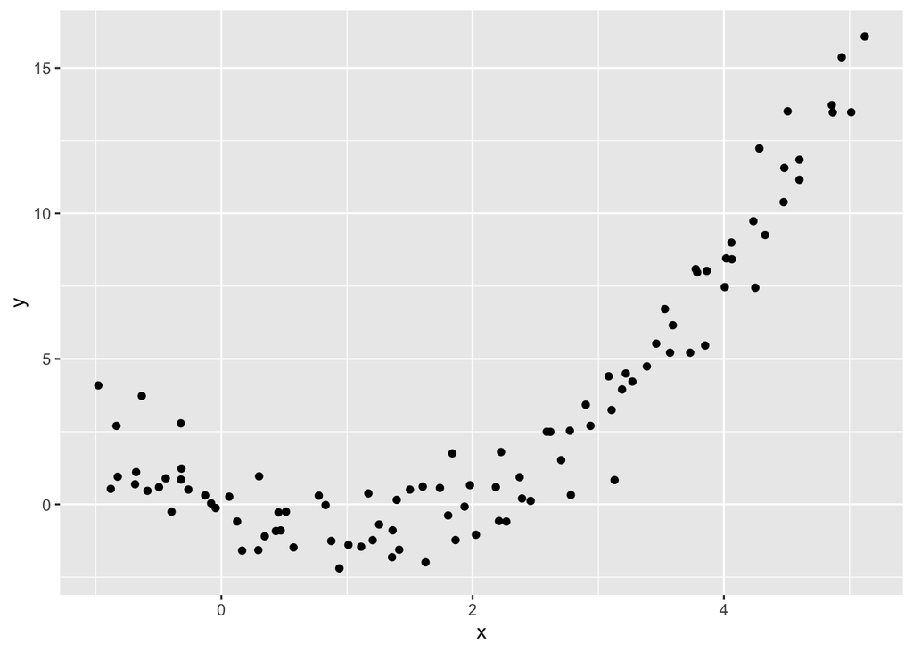

```r
n <- 100
df <- tibble(x = seq(-1, 5, length.out = n) + rnorm(n, sd = 0.1),
             y = x^2 - 2*x + rnorm(n))

ggplot(df, aes(x, y)) +
  geom_point()
```

Строить линейную регрессию на таких данных не кажется разумным.

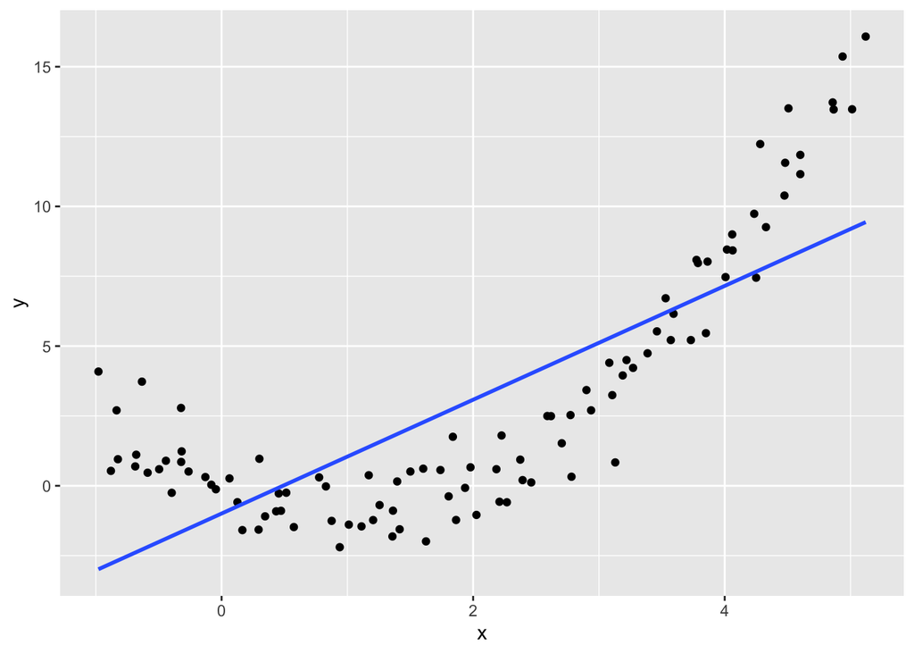

```r
ggplot(df, aes(x, y)) +
  geom_point() +
  geom_smooth(method = 'lm', se = F)
```

Красная линия более удачная модель для наших данных.

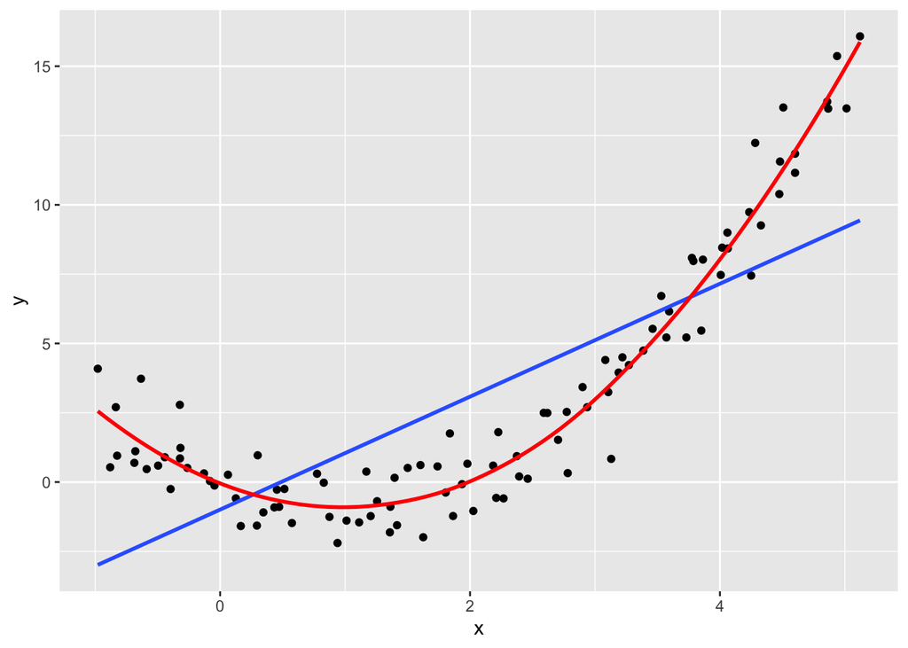

```r
ggplot(df, aes(x, y)) +
  geom_point() +
  geom_smooth(method = 'lm', se = F) +
  geom_smooth(se = F, color = 'red')
```

Чтобы построить такую модель можно использовать полиномы признака x: квадрата, кубы и так далее. Давайте попробуем взять квадрат этой модели и обучить нашу модель.

**Вариант 1**

```r
df <- df %>%
  mutate(x2 = x**2)
model <- lm(y ~ x + x2, data = df)
model
```

```
##
## Call:
## lm(formula = y ~ x + x2, data = df)
##
## Coefficients:
## (Intercept)            x           x2
##    -0.09175     -1.86596      0.97371
```

**Вариант 2**

```r
model <- lm(y ~ x + I(x^2), data = df)
model
```

```
##
## Call:
## lm(formula = y ~ x + I(x^2), data = df)
##
## Coefficients:
## (Intercept)            x       I(x^2)
##    -0.09175     -1.86596      0.97371
```

**Вариант 3**

```r
model <- lm(y ~ poly(x, 2, raw=T), data = df)
model
```

```
##
## Call:
## lm(formula = y ~ poly(x, 2, raw = T), data = df)
##
## Coefficients:
##          (Intercept)  poly(x, 2, raw = T)1  poly(x, 2, raw = T)2
##             -0.09175              -1.86596               0.97371
```

Визуализируем нашу модель.

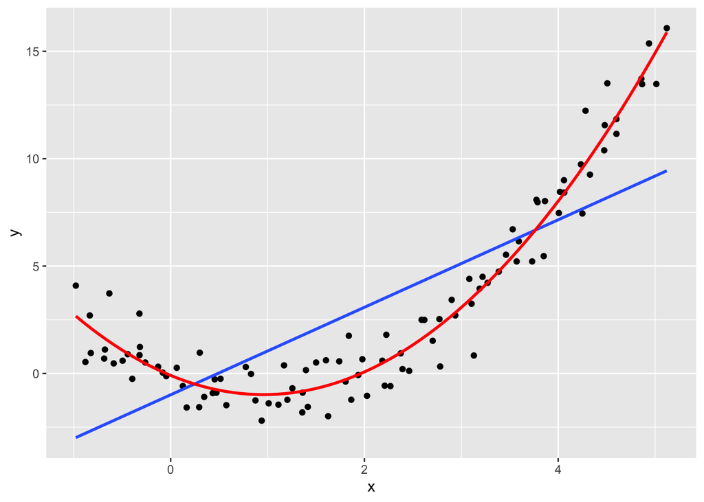

```r
ggplot(df, aes(x, y)) +
  geom_point() +
  geom_smooth(method = 'lm', se = F) +
  geom_smooth(method = 'lm', formula = y ~ poly(x, 2, raw=T), se = F, col='red')
```

Изначально мы не знали сколько полиномов нужно взять. Давайте возьмем больше.

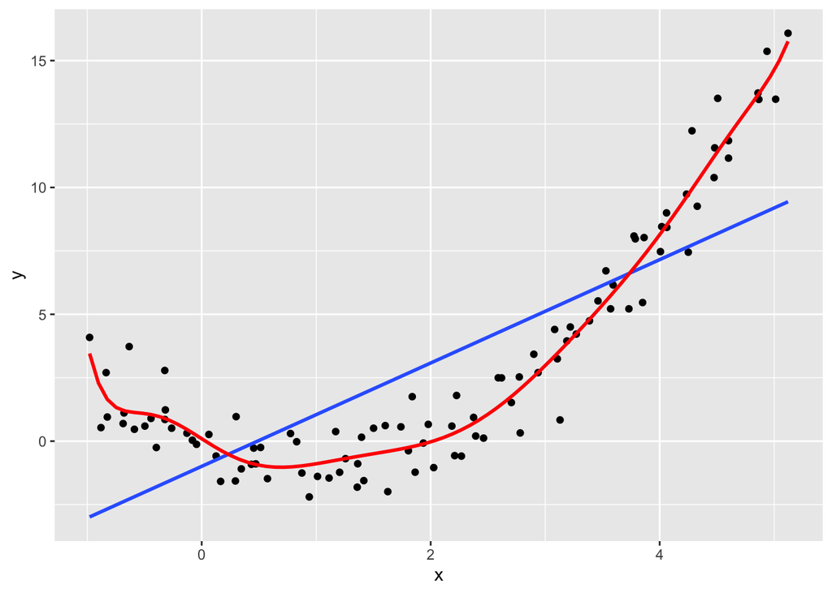

```r
ggplot(df, aes(x, y)) +
  geom_point() +
  geom_smooth(method = 'lm', se = F) +
  geom_smooth(method = 'lm', formula = y ~ poly(x, 10, raw=T), se = F, col='red')
```

```r
model <- lm(y ~ poly(x, 10, raw=T), data = df)
```

Видно, что такая модель начинает подгоняться под наши данные. В машинном обучении этот факт называется **переобученим**.

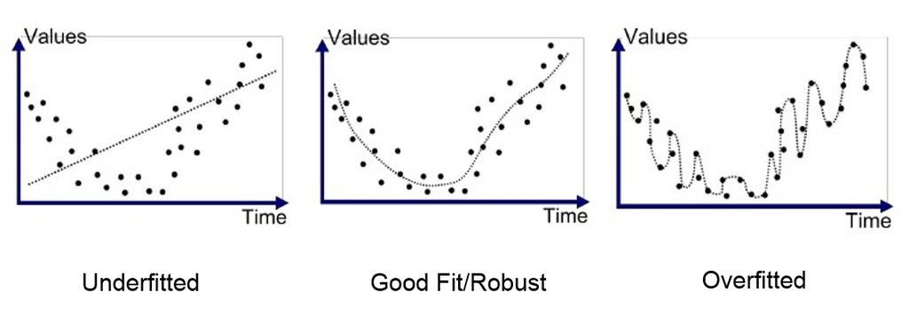

Модель показывает себя хорошо на этих данных, но если попробовать дать этой модели новые данные, то ошибка на этих новых данных будет выше чем на старых. В машинном обучении очень много сложных моеделй, с помощью которых можно легко допустить переобучение.

### Train and test

Чтобы контролировать эффект переобучения принято делить данные на тренировочные(train) и тестовые(test). На тренировочном датасете мы учимся, а на тестовом смотрим результаты нашей модели и оцениваем насколько модель хороша. Обычно набор данных делят 70 (train) на 30 (test).

Сгененрируем очень простой датасет.

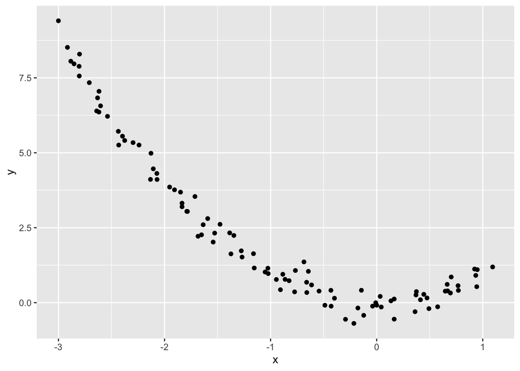

```r
n <- 100
df <- tibble(x = seq(-3, 1, length.out = n) + rnorm(n, sd = 0.1),
             y = x^2 + rnorm(n, sd = 0.3))

ggplot(df, aes(x, y)) +
  geom_point()
```

Попробуем поделить наши данные на 2 части.

```r
df <- df %>%
  arrange(x) %>%
  mutate(type = c(rep('Train', n*0.7), rep('Test', n*0.3)))
```

Визуализируем.

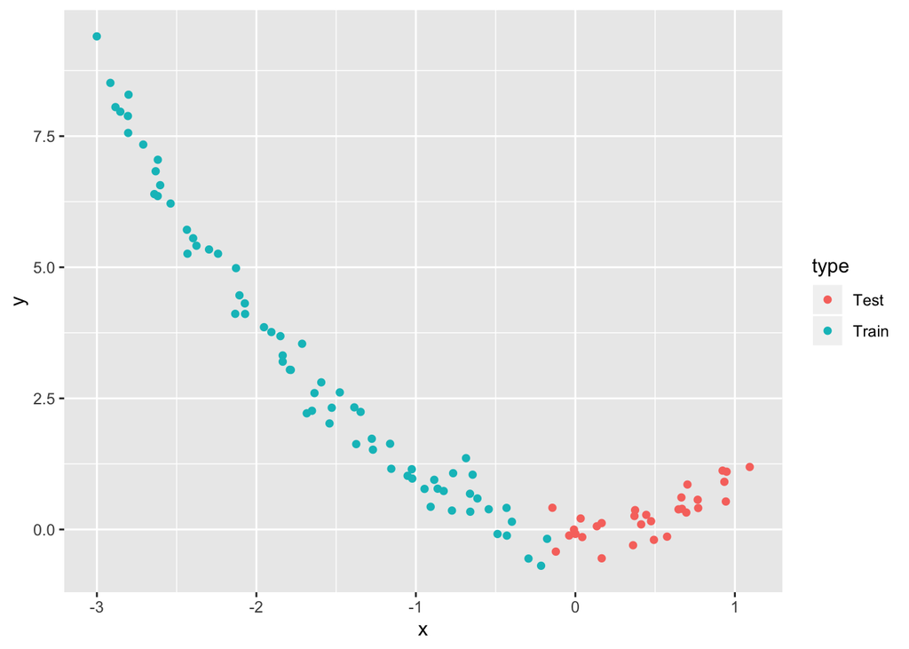

```r
ggplot(df, aes(x, y, color = type)) +
  geom_point()
```

Если обучить линейную регрессию на тренировочных данных, то мы получим следующий результат.

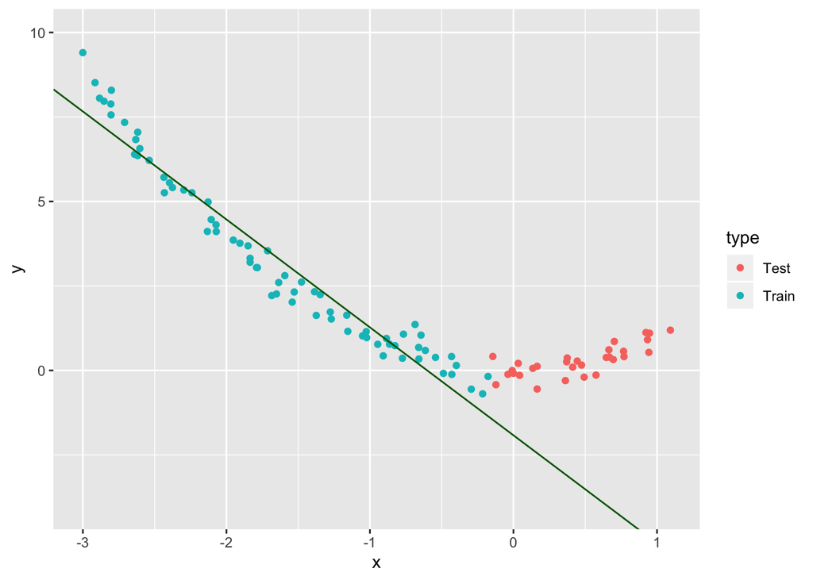

```r
train <- df %>% filter(type == 'Train')
test <- df %>% filter(type == 'Test')

model <- lm(y ~ x, data = train)
coeff <- model$coefficients

ggplot(df, aes(x, y, color = type)) +
  geom_point() +
  geom_abline(intercept = coeff[1], slope = coeff[2], color = 'darkgreen') +
  ylim(-4, 10)
```

Прогноз на тестовых данных будет очень плохим. Это происходит, так как модель не видела данные при х больше 0. При делении данных на train и test нужно перемешивать ваши данные.

```r
set.seed(42)
n <- 200
df <- tibble(x = seq(-3, 1, length.out = n) + rnorm(n, sd = 0.1),
             y = x^2 + rnorm(n, sd = 0.3))


library(rsample)

spliter <- initial_split(df, prop = 0.7)

train <- training(spliter)
test <- testing(spliter)

train$type <- 'Train'
test$type <- 'Test'

data <- bind_rows(train, test)
```

Визуализируем.

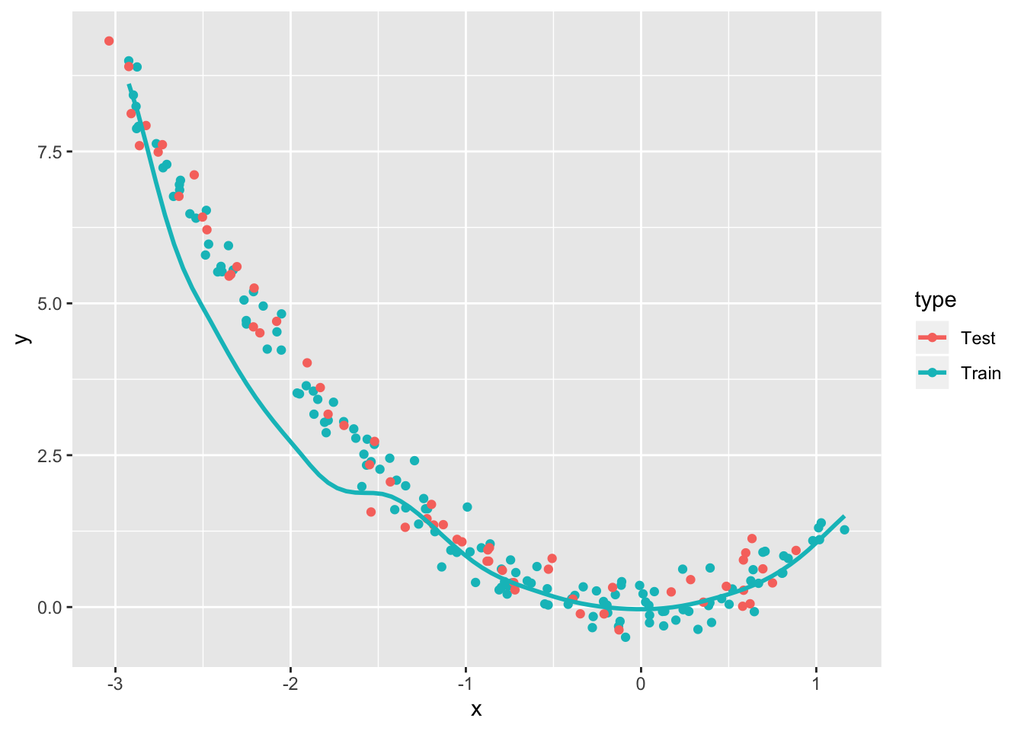

```r
ggplot(data, aes(x, y, color = type)) +
  geom_point() +
  geom_smooth(data = train, se = F, formula = y ~ poly(x, 2, raw = T))
```